# Projekt 1

# Przygotowanie

## Wczytanie bibliotek

Pierwsze trzeba się upewnić, czy wszystkie potrzebne biblioteki są zainstalowane i wczytane.

```r
#install.packages("aTSA")
#install.packages("forecast")
library('aTSA')
library('forecast')
```

## Wczytanie danych

Czas wczytać dane. Jest to rzeczywisty produkt krajowy brutto na mieszkańca USA.Zapiszmy od razu je jako szereg czasowy.

```r
data=read.csv('A939RX0Q048SBEA.csv')
data=ts(data$VALUE,frequency = 4)
```

Teraz pora na przyjrzenie się danym.

```r
eda<-c(min(data),max(data),max(data)-min(data),mean(data),is.null(data))
names(eda)<-c('Min ','Max ','Max-Min ','Średnia ',' Ile null')
(eda)
```

```
##      Min       Max   Max-Min   Średnia   Ile null
##  14009.00  60181.00  46172.00  34418.81      0.00
```

```r
head(data,n=8)
```

```
##    Qtr1  Qtr2  Qtr3  Qtr4
## 1 14213 14111 14018 14171
## 2 14326 14505 14525 14474
```

```r
tail(data,n=8)
```

```
##     Qtr1  Qtr2  Qtr3  Qtr4
## 74                   57005
## 75 57889 58864 59202 60154
## 76 59877 59756 60181
```

Wygląda na to, że wszystko wczytało się poprawnie. Nie występują brakujące wartości. Przejdźmy więc do główniej części.

# Główna część

## Badanie oryginalnego szeregu

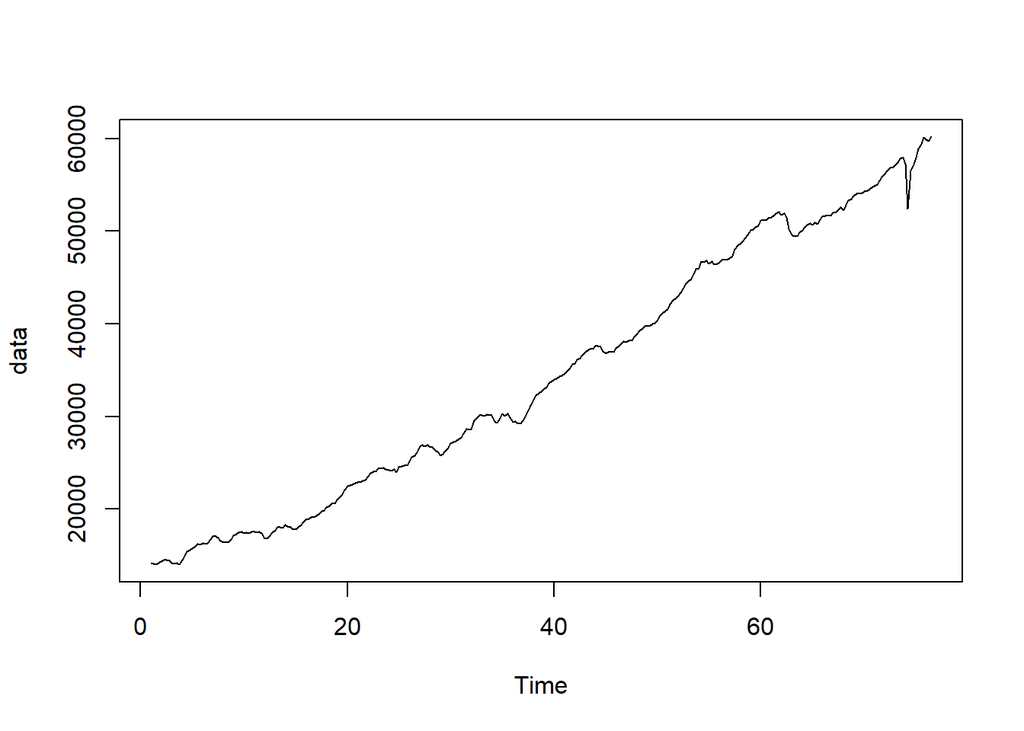

```r
plot(data)
```

Możemy zauważyć wyraźny tręd. Spróbujmy jednk rozbić ten szereg na poszcze składowe.

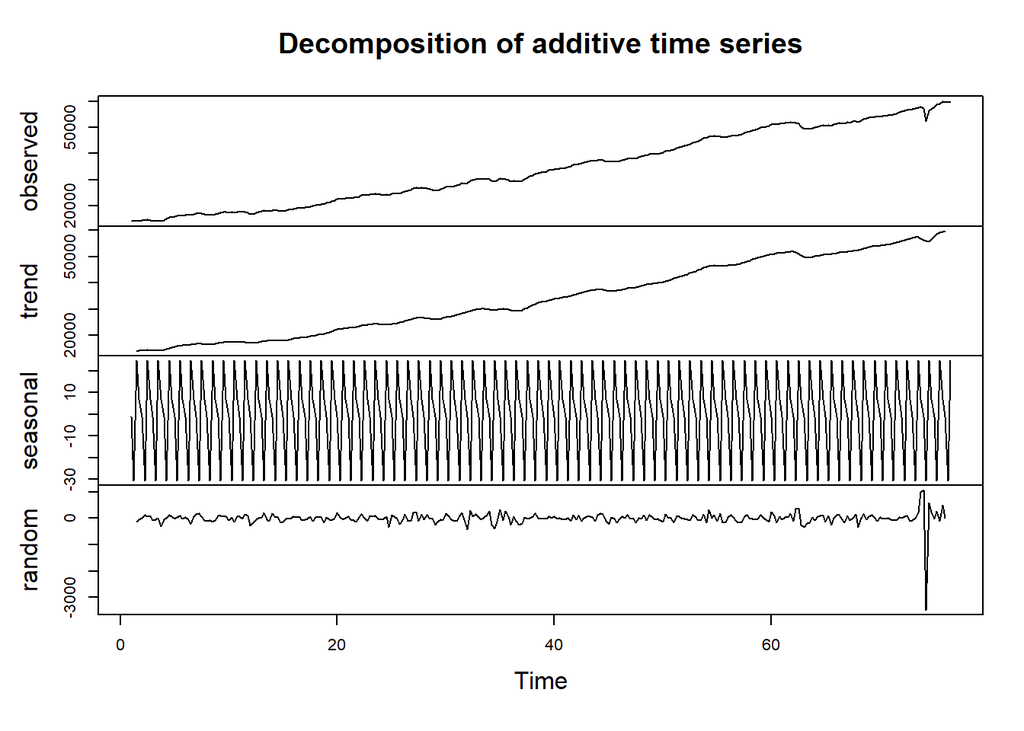

```r
plot(decompose((data)))
```

Sprawdźmy funkcje autokorelacji i autokorelacji cząstkowej

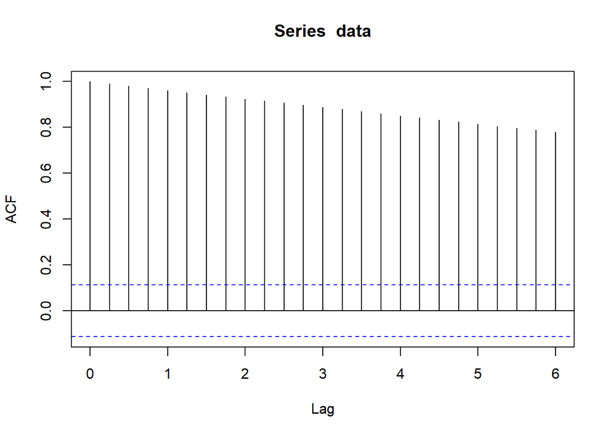

```r
acf(data)
```

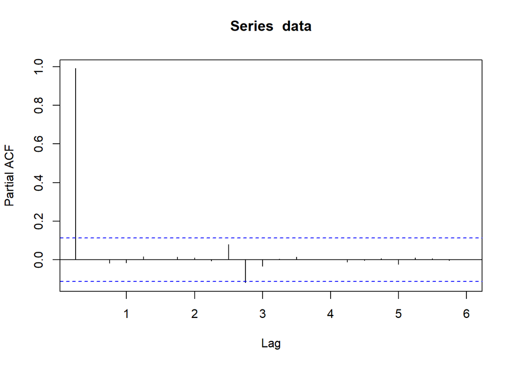

```r
pacf(data)
```

oraz test na stacjonarność szeregu.

```r
adf.test(data)
```

```
## Augmented Dickey-Fuller Test
## alternative: stationary
##
## Type 1: no drift no trend
##      lag  ADF p.value
## [1,]   0 5.65    0.99
## [2,]   1 5.91    0.99
## [3,]   2 5.37    0.99
## [4,]   3 5.04    0.99
## [5,]   4 5.08    0.99
## [6,]   5 4.84    0.99
## Type 2: with drift no trend
##      lag   ADF p.value
## [1,]   0 0.869    0.99
## [2,]   1 0.965    0.99
## [3,]   2 0.869    0.99
## [4,]   3 0.857    0.99
## [5,]   4 0.946    0.99
## [6,]   5 0.951    0.99
## Type 3: with drift and trend
##      lag   ADF p.value
## [1,]   0 -2.87   0.210
## [2,]   1 -2.65   0.304
## [3,]   2 -2.67   0.295
## [4,]   3 -2.71   0.276
## [5,]   4 -2.65   0.304
## [6,]   5 -2.68   0.288
## ----
## Note: in fact, p.value = 0.01 means p.value <= 0.01
```

W każdym wypadku p-value jest zdecydowanie większe niż 0.05 wię nie mamy przesłanek za odrzuceniem hipotezy zerowej. W takim przypadku przyjmimy, że szereg nie jest stacjonarny. Co jednak będzie jeśli go zróżnicujemy?

## Różnicowanie szeregu

```r
data_dif<-diff(data,1)
```

Analogicznie sprawdźmy, czy nic się nie zepsuło w danych.

```r
eda<-c(min(data_dif),max(data_dif),max(data_dif)-min(data_dif),mean(data_dif),is.null(data_dif))
names(eda)<-c('Min ','Max ','Max-Min ','Średnia ',' Ile null')
(eda)
```

```
##       Min        Max    Max-Min    Średnia    Ile null
## -4885.0000  4090.0000  8975.0000   152.2119     0.0000
```

```r
head(data_dif,n=8)
```

```
##   Qtr1 Qtr2 Qtr3 Qtr4
## 1      -102  -93  153
## 2  155  179   20  -51
## 3 -262
```

```r
tail(data_dif,n=8)
```

```
##    Qtr1 Qtr2 Qtr3 Qtr4
## 74                 521
## 75  884  975  338  952
## 76 -277 -121  425
```

Wszystko wygląda dobrze. Rozłóżmy więc szereg na czynniki.

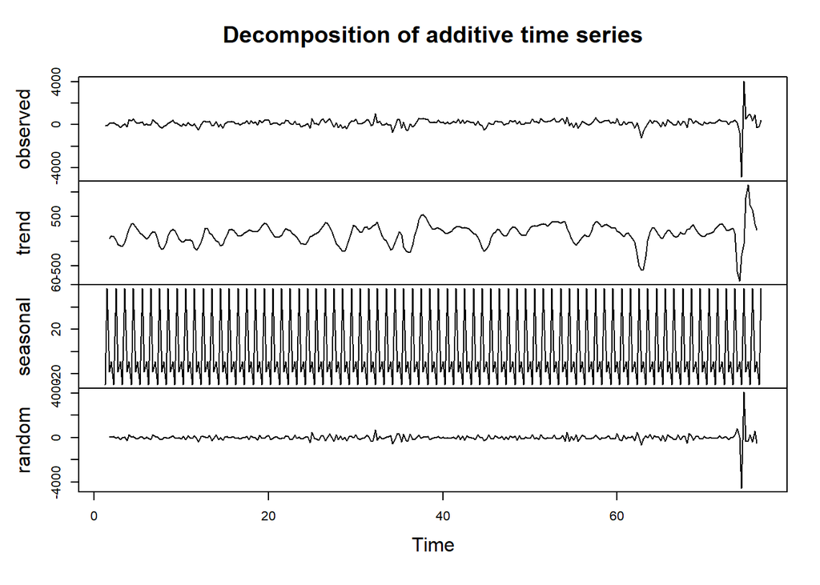

```r
plot(decompose(data_dif))
```

Jest on teraz zdecydowanie bardziej wypłaszczony. Możliwe, że w takiej formie okaże się stacjonarny.

Sprawdźmy funkcje autokorelacji i autokorelacji cząstkowej

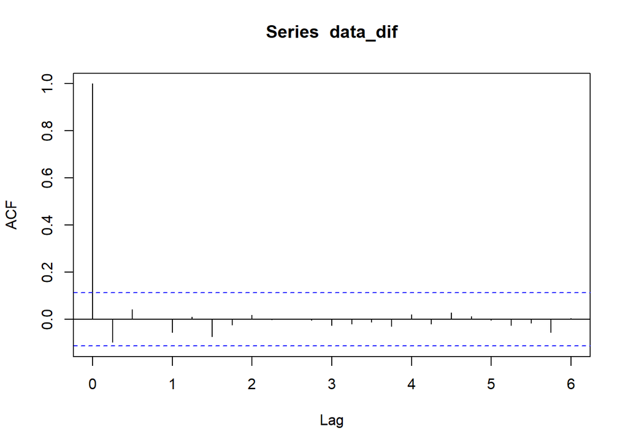

```r
acf(data_dif)
```

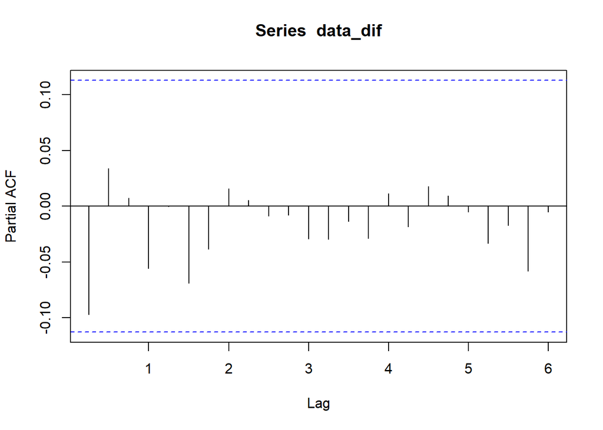

```r
pacf(data_dif)
```

oraz stacjonarność

```r
adf.test(data_dif)
```

```
## Augmented Dickey-Fuller Test
## alternative: stationary
##
## Type 1: no drift no trend
##      lag    ADF p.value
## [1,]   0 -17.10    0.01
## [2,]   1 -10.55    0.01
## [3,]   2  -8.12    0.01
## [4,]   3  -7.09    0.01
## [5,]   4  -5.99    0.01
## [6,]   5  -5.54    0.01
## Type 2: with drift no trend
##      lag    ADF p.value
## [1,]   0 -19.06    0.01
## [2,]   1 -12.36    0.01
## [3,]   2  -9.93    0.01
## [4,]   3  -9.07    0.01
## [5,]   4  -7.98    0.01
## [6,]   5  -7.73    0.01
## Type 3: with drift and trend
##      lag    ADF p.value
## [1,]   0 -19.12    0.01
## [2,]   1 -12.42    0.01
## [3,]   2 -10.00    0.01
## [4,]   3  -9.16    0.01
## [5,]   4  -8.09    0.01
## [6,]   5  -7.85    0.01
## ----
## Note: in fact, p.value = 0.01 means p.value <= 0.01
```

W każdym wypadku zaobserwowane p-value pozwala nam przyjąć hipotezę alternatywną. Uznajemy więc że szereg ten jest stacjonarny po jednokrotnym zróżnicowaniu.

## Przyporządkowanie Arimy i prognozowanie

Spróbujmy przyporządkować model Arima do naszych danych

```r
fit<-auto.arima(data,)
fit
```

```
## Series: data
## ARIMA(0,1,1) with drift
##
## Coefficients:
##           ma1     drift
##       -0.0902  152.2167
## s.e.   0.0551   23.9076
##
## sigma^2 = 209793:  log likelihood = -2277.86
## AIC=4561.71   AICc=4561.79   BIC=4572.84
```

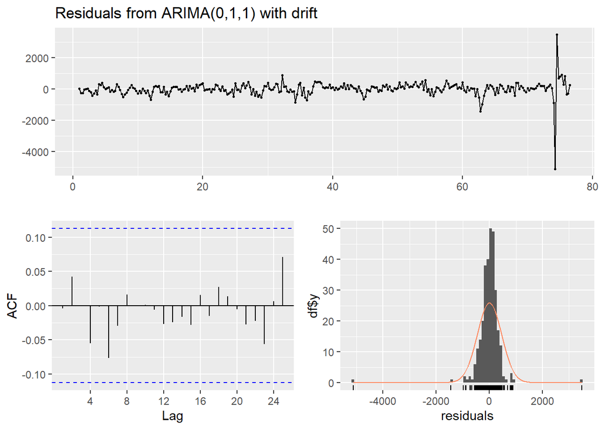

```
##
##  Ljung-Box test
##
## data:  Residuals from ARIMA(0,1,1) with drift
## Q* = 3.6818, df = 7, p-value = 0.8156
##
## Model df: 1.   Total lags used: 8
```

```r
checkresiduals(fit)
```

```r
shapiro.test(fit$residuals)
```

```
##
##  Shapiro-Wilk normality test
##
## data:  fit$residuals
## W = 0.61449, p-value < 2.2e-16
```

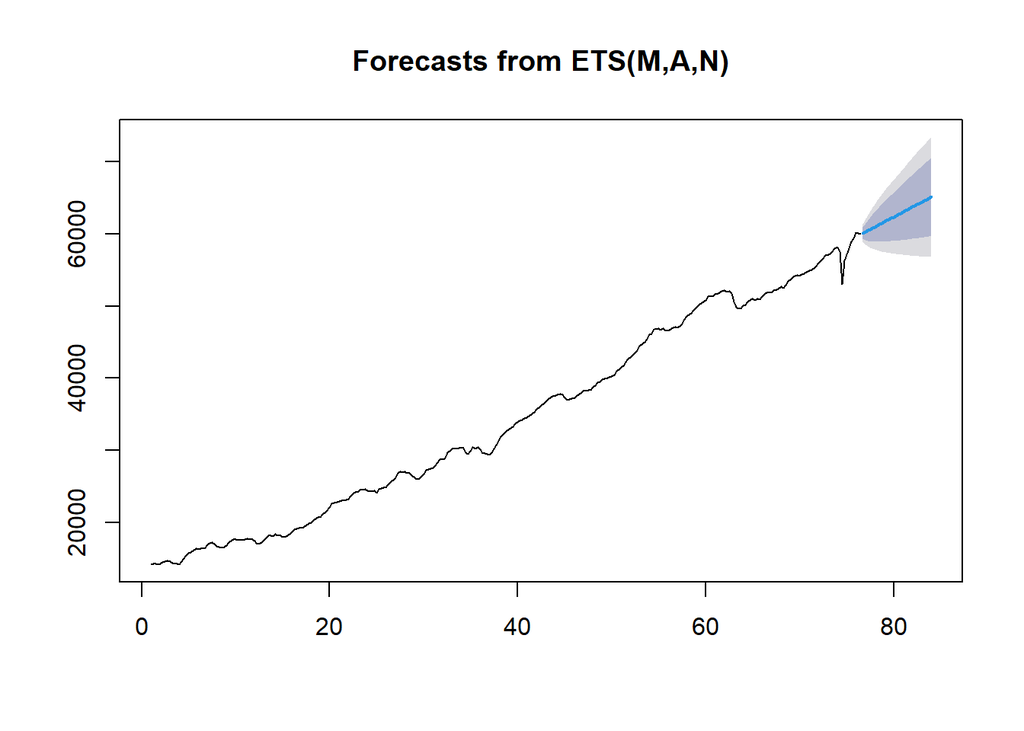

```r
plot(predict(fit$fitted,h=30))
```